# PYTHON PROGRAMING

```python
print("hello world")
```

```
hello world
```

```python
#comment
```

```python
#variabel
x = 2
y = x + 2
```

```python
#comment
from platform import python_version
print(python_version())
```

```
3.12.11
```

```python
#data type
x = 'hello world'
print(f"x: {x}")
print(f"type(x): {type(x)}")
x = 2
print(f"x: {x}")
print(f"type(x): {type(x)}")
x = 2.5
print(f"x: {x}")
print(f"type(x): {type(x)}")
x = 7j
print(f"x: {x}")
print(f"type(x): {type(x)}")
```

```
x: hello world
type(x): <class 'str'>
x: 2
type(x): <class 'int'>
x: 2.5
type(x): <class 'float'>
x: 7j
type(x): <class 'complex'>
```

```python
x = ["apple", "banana", "cherry"] #list
print(f"x: {x}")
print(f"type(x): {type(x)}")
x = ("apple", "banana", "cherry") #tuple
print(f"x: {x}")
print(f"type(x): {type(x)}")
x = range(6) #range
print(f"x: {x}")
print(f"type(x): {type(x)}")
x = {"name" : "Tom", "age" : 20} #dict
print(f"x: {x}")
print(f"type(x): {type(x)}")
x = {"apple", "banana", "cherry"} #set
print(f"x: {x}")
print(f"type(x): {type(x)}")
x = frozenset({"apple", "banana", "cherry"})
print(f"x: {x}")
print(f"type(x): {type(x)}")
```

```
x: ['apple', 'banana', 'cherry']
type(x): <class 'list'>
x: ('apple', 'banana', 'cherry')
type(x): <class 'tuple'>
x: range(0, 6)
type(x): <class 'range'>
x: {'name': 'Tom', 'age': 20}
type(x): <class 'dict'>
x: {'apple', 'banana', 'cherry'}
type(x): <class 'set'>
x: frozenset({'apple', 'banana', 'cherry'})
type(x): <class 'frozenset'>
```

```python
x = True #bool
print(f"x: {x}")
print(f"type(x): {type(x)}")
x = b"Hello" #bytes
print(f"x: {x}")
print(f"type(x): {type(x)}")
x = bytearray(5) #bytearray
print(f"x: {x}")
print(f"type(x): {type(x)}")
x = memoryview(bytes(5)) #memoryview
print(f"x: {x}")
print(f"type(x): {type(x)}")
x = None #NoneType
print(f"x: {x}")
print(f"type(x): {type(x)}")
```

```
x: True
type(x): <class 'bool'>
x: b'Hello'
type(x): <class 'bytes'>
x: bytearray(b'\x00\x00\x00\x00\x00')
type(x): <class 'bytearray'>
x: <memory at 0x7f505822d600>
type(x): <class 'memoryview'>
x: None
type(x): <class 'NoneType'>
```

```python
#Python Casting
x = str(3) # x will be '3'
y = int(3) # y will be 3
z = float(3) # z will be 3.0
print(x, type(x))
print(y, type(y))
print(z, type(z))
```

```
3 <class 'str'>
3 <class 'int'>
3.0 <class 'float'>
```

```python
#Python Numbers
x = 2 # int
y = 3.4 # float
z = 7j #complex
print(x, type(x))
print(y, type(y))
print(z, type(z))
```

```
2 <class 'int'>
3.4 <class 'float'>
7j <class 'complex'>
```

```python
#Python Arithmetic Operators
print('7 + 2 =', 7 + 2)
print('7 - 2 =', 7 - 2)
print('7 * 2 =', 7 * 2)
print('7 / 2 =', 7 / 2)
print('7 // 2 =', 7 // 2)
print('7 % 2 =', 7 % 2)
print('7 ** 2 =', 7 ** 2)
```

```
7 + 2 = 9
7 - 2 = 5
7 * 2 = 14
7 / 2 = 3.5
7 // 2 = 3
7 % 2 = 1
7 ** 2 = 49
```

```python
# Python Booleans: True or False
print(3 > 2)
print(3 == 2)
print(3 < 2)
```

```
True
False
False
```

```python
for a, b in [(2,5), (5,2), (5,5)]:
    print("-"*50)
    print(f"a={a}, b={b}")
    print(f"a<b:[|a| < |b|]: {a<b}")
    print(f"a>b:[|a| > |b|]: {a>b}")
    print(f"a<=b:[|a| <= |b|]: {a<=b}")
    print(f"a>=b:[|a| >= |b|]: {a>=b}")
```

```
--------------------------------------------------
a=2, b=5
a<b:[|a| < |b|]: True
a>b:[|a| > |b|]: False
a<=b:[|a| <= |b|]: True
a>=b:[|a| >= |b|]: False
--------------------------------------------------
a=5, b=2
a<b:[|a| < |b|]: False
a>b:[|a| > |b|]: True
a<=b:[|a| <= |b|]: False
a>=b:[|a| >= |b|]: True
--------------------------------------------------
a=5, b=5
a<b:[|a| < |b|]: False
a>b:[|a| > |b|]: False
a<=b:[|a| <= |b|]: True
a>=b:[|a| >= |b|]: True
```

```python
# BMI Calculator in Python
height_cm = 170
weight_kg = 60
height_m = height_cm/100
BMI = (weight_kg/(height_m**2))

print("Your BMI is: " + str(round(BMI,1)))
```

```
Your BMI is: 20.8
```

```python
# How much is your $100 worth after 7 years?
fv = 100 * 1.1 ** 7
print('fv = ', round(fv, 2))
# output = 194.87
```

```
fv =  194.87
```

```python
# Future Value
pv = 100
r = 0.1
n = 7
fv = pv * ((1 + (r)) ** n)
print(round(fv, 2))
```

```
194.87
```

```python
# Future Value
amount = 100
interest = 10 #10% = 0.01 * 10
years = 7

future_value = amount * ((1 + (0.01 * interest)) ** years)
print(round(future_value, 2))
```

```
194.87
```

KẾT THÚC

## DATA STRUCTURE

```python
#Python Data Types
x = ["apple", "banana", "cherry"] #list
print(f"x: {x}")
print(f"type(x): {type(x)}")
x = ("apple", "banana", "cherry") #tuple
print(f"x: {x}")
print(f"type(x): {type(x)}")
x = {"name" : "Tom", "age" : 20} #dict
print(f"x: {x}")
print(f"type(x): {type(x)}")
x = {"apple", "banana", "cherry"} #set
print(f"x: {x}")
print(f"type(x): {type(x)}")
```

```
x: ['apple', 'banana', 'cherry']
type(x): <class 'list'>
x: ('apple', 'banana', 'cherry')
type(x): <class 'tuple'>
x: {'name': 'Tom', 'age': 20}
type(x): <class 'dict'>
x: {'apple', 'banana', 'cherry'}
type(x): <class 'set'>
```

```python
#list
x = [60, 70, 80, 90]
print(len(x))
print(x[0])
print(x[1])
print(x[-1])
```

```
4
60
70
90
```

```python
#tuple()
x = (10, 20, 30, 40, 50)
print(x[0])
print(x[1])
print(x[2])
print(x[-1])
```

```
10
20
30
50
```

```python
#set
animals = {'cat', 'dog'}
print('cat' in animals)
print('fish' in animals)
animals.add('fish')
print('fish' in animals)
print(len(animals))
animals.add('cat')
print(len(animals))
animals.remove('cat')
print(len(animals))
```

```
True
False
True
3
3
2
```

```python
k = { 'EN':'English','FR':'French' }
print(k['EN'])
```

```
English
```

```python
fruits = ["apple", "banana", "cherry"] #lists []
colors = ("red", "green", "blue") #tuples ()
animals = {'cat', 'dog'} #sets {}
person = {"name" : "Tom", "age" : 20} #dictionaries {}
```

Python for Finance Applications

```python
# Python Lists
expenses = [72.50, 80.75, 50.00, 90.25]
total_expenses = sum(expenses)
print("Total expenses:", total_expenses)
```

```
Total expenses: 293.5
```

```python
# Python Tuples
accounts = (("Cash", 1001), ("Accounts Receivable", 1002),
("Inventory", 1003))
for account in accounts:
  print("Account name:", account[0], "Account number:", account[1])
```

```
Account name: Cash Account number: 1001
Account name: Accounts Receivable Account number: 1002
Account name: Inventory Account number: 1003
```

```python
# Python Sets
account_numbers = {1001, 1002, 1003}
new_account_number = 1004
if new_account_number not in account_numbers:
  print("Account number", new_account_number, "is not in use.")
```

```
Account number 1004 is not in use.
```

```python
# Python Dictionaries
accounts = {
    "1001": {"name": "Cash", "balance": 500.00, "type": "Asset"},
    "1002": {"name": "Accounts Receivable", "balance": 1000.00, "type": "Asset"},
    "2001": {"name": "Accounts Payable", "balance": 750.00, "type": "Liability"}
    }
for account_number, account_info in accounts.items():
  print("Account number:", account_number)
  print("Account name:", account_info["name"])
  print("Account balance:", account_info["balance"])
  print("Account type:", account_info["type"])
```

```
Account number: 1001
Account name: Cash
Account balance: 500.0
Account type: Asset
Account number: 1002
Account name: Accounts Receivable
Account balance: 1000.0
Account type: Asset
Account number: 2001
Account name: Accounts Payable
Account balance: 750.0
Account type: Liability
```

KẾT THÚC

## Python Control Logic and Loops

```python
# Python if
score = 80
if score >=60 :
  print("Pass")
```

```
Pass
```

```python
# Python if else
score = 80
if score >=60 :
  print("Pass")
else:
  print("Fail")
```

```
Pass
```

```python
score = 95
if score >= 90 :
  print("A")
elif score >=60 :
  print("Pass")
else:
  print("Fail")
```

```
A
```

```python
# Python if elif else
score = 90
grade = ""
if score >=90:
  grade = "A"
elif score >= 80:
  grade = "B"
elif score >= 70:
  grade = "C"
elif score >= 60:
  grade = "D"
else:
  grade = "E"
print(grade)
```

```
A
```

```python
for i in range(1,6):
  print(i)
```

```
1
2
3
4
5
```

```python
# for loops
for i in range(1,10):
  for j in range(1,10):
    print(i, ' * ' , j , ' = ', i*j)
```

```
1  *  1  =  1
1  *  2  =  2
1  *  3  =  3
1  *  4  =  4
1  *  5  =  5
1  *  6  =  6
1  *  7  =  7
1  *  8  =  8
1  *  9  =  9
2  *  1  =  2
2  *  2  =  4
2  *  3  =  6
2  *  4  =  8
2  *  5  =  10
2  *  6  =  12
```

[output cut: 66 more lines]

```python
# while loops
age = 10
while age < 20:
  print(age)
  age = age + 1
```

```
10
11
12
13
14
15
16
17
18
19
```

Kết thúc

## PYTHON FUNCTION

```python
# Python Function def
# indentation for blocks. four spaces
def getfv(pv, r, n):
  fv = pv * ((1 + (r)) ** n)
  return fv
fv = getfv(100, 0.1, 7)
print(round(fv, 2))
```

```
194.87
```

```python
# How much is your $100 worth after 7 years?
fv = 100 * 1.1 ** 7
print('fv = ', round(fv, 2))
# output = 194.87
```

```
fv =  194.87
```

```python
# Future Value
pv = 100
r = 0.1
n = 7
fv = pv * ((1 + (r)) ** n)
print(round(fv, 2))
```

```
194.87
```

```python
# Future Value
amount = 100
interest = 10 #10% = 0.01 * 10
years = 7

future_value = amount * ((1 + (0.01 * interest)) ** years)
print(round(future_value, 2))
```

```
194.87
```

```python
# Python Function def
# indentation for blocks. four spaces
def getfv(pv, r, n):
  fv = pv * ((1 + (r)) ** n)
  return fv
fv = getfv(100, 0.1, 7)
print(round(fv, 2))
```

```
194.87
```

Kết thúc

## PYTHON CLASSES/ OBJECTS

```python
# Python class
class MyClass:
  x = 5
c1 = MyClass()
print(c1.x)
```

```
5
```

```python
class Person:
  def __init__(self, name, age):
    self.name = name
    self.age = age
p1 = Person("Alan", 20)

print(p1.name)
print(p1.age)
```

```
Alan
20
```

```python
class Person:
  def __init__(self, name, age):
    self.name = name
    self.age = age
  def myfunc(self):
    print("Hello my name is " + self.name)
p1 = Person("Alan", 20)
p1.myfunc()
```

```
Hello my name is Alan
```

```python
class Person:
  def __init__(self, name, age):
    self.name = name
    self.age = age
  def myfunc(self):
    print("Hello my name is " + self.name)

p1 = Person("Alan", 20)
p1.myfunc()
print(p1.name)
print(p1.age)
```

```
Hello my name is Alan
Alan
20
```

```python
class Vehicle:
  name = ""
  kind = "car"
  color = ""
  value = 100.00
  def description(self):
    desc_str = "%s is a %s %s worth $%.2f." % (self.name, self.color, self.kind, self.value)
    return desc_str
```

```python
car1 = Vehicle()
car1.name = "Fer"
car1.color = "red"
car1.kind = "convertible"
car1.value = 60000.00

car2 = Vehicle()
car2.name = "Jump"
car2.color = "blue"
car2.kind = "van"
car2.value = 10000.00

print(car1.description())
print(car1.name)
print(car2.description())
print(car2.name)
```

```
Fer is a red convertible worth $60000.00.
Fer
Jump is a blue van worth $10000.00.
Jump
```

```python
class Vehicle:
  name = ""
  kind = "car"
  color = ""
  value = 100.00
  def description(self):
    desc_str = "%s is a %s %s worth $%.2f." % (self.name, self.color, self.kind, self.value)
    return desc_str
```

kết thúc

## PYTHON MODULES

```python
# Python File Input / Output
with open('myfile.txt', 'w') as file:
  file.write('Hello World\nThis is Python File Input Output')
with open('myfile.txt', 'r') as file:
  text = file.read()
print(text)
```

```
Hello World
This is Python File Input Output
```

```python
# Python File Input / Output
filename = 'mymodule.py'
with open(filename, 'w') as file:
  text = '''def greeting(name):
  print("Hello, " + name)
  '''
  file.write(text)

with open(filename, 'r') as file:
  text = file.read()

print(filename)
print(text)
```

```
mymodule.py
def greeting(name):
  print("Hello, " + name)
```

```python
#Python main() function
def main():
  print("Hello World!")

if __name__ == "__main__":
  main()
```

```
Hello World!
```

## FILES AND EXCEPTION HANDLING

```python
f = open("myfile.txt", "w")
f.write("Hello World")
f.close()

f = open("myfile.txt", "r")
text = f.read()
print(text)
f.close()
```

```
Hello World
```

```python
with open('myfile.txt', 'w') as file:
  file.write('Hello World')

with open('myfile.txt', 'r') as file:
  text = file.read()
print(text)
```

```
Hello World
```

```python
# Python File Input / Output
with open('myfile.txt', 'w') as file:
  file.write('Hello World\nPython File IO')

with open('myfile.txt', 'r') as file:
  text = file.read()
print(text)
```

```
Hello World
Python File IO
```

```python
# Python File Input / Output
with open('myfile.txt', 'a+') as file:
  file.write('\n' + 'New line')

with open('myfile.txt', 'r') as file:
  text = file.read()
print(text)
```

```
Hello World
Python File IO
New line
```

```python
# !ls list files
!ls
```

```
myfile.txt  mymodule.py  sample_data
```

```python
#Python OS, IO, files, and Google Drive
import os

cwd = os.getcwd()
print(cwd)
```

```
/content
```

```python
os.listdir(cwd)
```

```
['.config', 'myfile.txt', 'mymodule.py', 'sample_data']
```

```python
path = os.path.join(cwd,'sample_data')

print(path)
os.listdir(path)
```

```
/content/sample_data
```

```
['anscombe.json',
 'README.md',
 'mnist_test.csv',
 'mnist_train_small.csv',
 'california_housing_train.csv',
 'california_housing_test.csv']
```

```python
from google.colab import files

with open('io_file_myday.txt', 'w') as f:
  f.write('Google Colab File Write Text some content Myday')

import time
time.sleep(1) # time sleep 1 second

files.download('io_file_myday.txt')
print('downloaded')
```

```
downloaded
```

```python
from google.colab import files
uploaded = files.upload()

for fn in uploaded.keys():
  print('User uploaded file "{name}" with length {length} bytes'.format(name=fn, length=len(uploaded[fn])))
```

Upload widget is only available when the cell has been executed in the current browser session. Please rerun this cell to enable.

```python
import os
if os.path.exists("myfile.txt"):
  os.remove("myfile.txt")
  print("myfile.txt removed")
else:
  print("The file does not exist")
```

```
myfile.txt removed
```

```python
import os
os.listdir()
os.mkdir("myfolder1")
os.listdir()
os.rmdir("myfolder1")
os.listdir()
```

```
['.config', 'io_file_myday.txt', 'mymodule.py', 'sample_data']
```

```python
#Python try except
try:
  print(x)
except:
  print("Exception Error")
```

```
(10, 20, 30, 40, 50)
```

```python
#Python try except finally
try:
  print("Hello")
except:
  print("Exception Error")
finally:
  print("Finally process")
```

```
Hello
Finally process
```

```python
#Python try except else
try:
  print("Hello")
except:
  print("Exception Error")
else:
  print("No exception")
```

```
Hello
No exception
```

```python
try:
  print("Hello")
except:
  print("Exception Error")
else:
  print("No exception")
finally:
  print("Finally process")
```

```
Hello
No exception
Finally process
```

```python
try:
  price = float(input("Enter the price of the stock (e.g. 10):"))
  shares = int(input("Enter the number of shares (e.g. 2):"))
  total = price * shares
except Exception as e:
  print("Exception error:", str(e))
else:
  print("The total value of the shares is:", total)
finally:
  print("Thank you.")
```

```
Enter the price of the stock (e.g. 10):10
Enter the number of shares (e.g. 2):10
The total value of the shares is: 100.0
Thank you.
```

```python
try:
  file = open("myfile.txt")
  file.write("Python write file")
  print("file saved")
except:
  print("Exception file Error")
```

```
Exception file Error
```

```python
try:
  file = open("myfile.txt")
  file.write("Python write file")
  print("file saved")
except:
  print("Exception file Error")
finally:
  file.close()
  print("Finally process")
```

```
Exception file Error
Finally process
```

```python
try:
  file = open ("myfile.txt", 'w')
  file.write("Python write file")
  print("file saved")
except:
  print("Exception file Error")
finally:
  file.close()
print("Finally process")
```

```
file saved
Finally process
```

KẾT THÚC

# Data Analytics and Visualization **with** Python

## NUMPY

```python
v = list(range(1, 6))
v
2 * v
import numpy as np
v = np.arange(1, 6)
v
2 * v
```

```
array([ 2,  4,  6,  8, 10])
```

```python
#NumPy Create Array
import numpy as np
a = np.array([1, 2, 3])
b = np.array([4, 5, 6])
c = a * b
c
```

```
array([ 4, 10, 18])
```

```python
import numpy as np

a = np.zeros((2, 2))    # Create an array of all zeros
print(a)                # [[0. 0.]
                        #  [0. 0.]]

b = np.ones((1, 2))     # Create an array of all ones
print(b)                # [[1. 1.]]

c = np.full((2, 2), 7)  # Create a constant array
print(c)                # [[7 7]
                        #  [7 7]]

d = np.eye(2)           # Create a 2x2 identity matrix
print(d)                # [[1. 0.]
                        #  [0. 1.]]

e = np.random.random((2, 2))  # Create an array filled with random values
print(e)
# Example output:
# [[0.91940167 0.08143941]
#  [0.68744134 0.87236687]]
```

```
[[0. 0.]
 [0. 0.]]
[[1. 1.]]
[[7 7]
 [7 7]]
[[1. 0.]
 [0. 1.]]
[[0.07357589 0.69599636]
 [0.45881105 0.53500503]]
```

```python
a = np.arange(15).reshape(3, 5)
print(a)
print(a.shape)
print(a.ndim)
a.dtype.name
```

```
[[ 0  1  2  3  4]
 [ 5  6  7  8  9]
 [10 11 12 13 14]]
(3, 5)
2
```

```
'int64'
```

NumPy ndarray: Multidimensional Array Object

```python
a = np.array([1,2,3,4,5])
a
```

```
array([1, 2, 3, 4, 5])
```

```python
a = np.array([[1,2,3,4,5],[6,7,8,9,10],[11,12,13,14,15],[16,17,18,19,20]])
a
```

```
array([[ 1,  2,  3,  4,  5],
       [ 6,  7,  8,  9, 10],
       [11, 12, 13, 14, 15],
       [16, 17, 18, 19, 20]])
```

```python
a = np.array([[0, 1, 2, 3],
[10, 11, 12, 13],
[20, 21, 22, 23]])
a
print(a.ndim)
print(a.shape)
```

```
2
(3, 4)
```

NumPy Basics: Arrays and Vectorized Computation

## PANDAS

```python
import pandas as pd
df = pd.DataFrame({ "a": [4, 5, 6],
                    "b": [7, 8, 9],
                    "c": [10, 11, 12]},
                    index = [1, 2, 3])
type(df)
```

```
pandas.core.frame.DataFrame
def __init__(data=None, index: Axes | None=None, columns: Axes | None=None, dtype: Dtype | None=None, copy: bool | None=None) -> None
```

[output not shown]

[output cut: 76 more lines]

[output not shown]

```python
import numpy as np
import pandas as pd
import matplotlib.pyplot as plt
print('pandas imported')
```

```
pandas imported
```

```python
s = pd.Series([1,3,5,np.nan,6,8])
s
```

|  | 0 |
| --- | --- |
| 0 | 1.0 |
| 1 | 3.0 |
| 2 | 5.0 |
| 3 | NaN |
| 4 | 6.0 |
| 5 | 8.0 |

**dtype:** float64

```python
dates = pd.date_range('20181001', periods=6)
dates
```

```
DatetimeIndex(['2018-10-01', '2018-10-02', '2018-10-03', '2018-10-04',
               '2018-10-05', '2018-10-06'],
              dtype='datetime64[ns]', freq='D')
```

```python
df = pd.DataFrame(np.random.randn(6,4), index=dates, columns=list('ABCD'))
df
```

|  | A | B | C | D |
| --- | --- | --- | --- | --- |
| 2018-10-01 | 1.221077 | 0.023592 | -0.718934 | 0.011971 |
| 2018-10-02 | -0.689010 | 0.318001 | -0.104137 | 0.307213 |
| 2018-10-03 | 1.550240 | -1.684627 | -2.040953 | 0.040762 |
| 2018-10-04 | 1.651869 | 0.439340 | 0.567288 | -2.017971 |
| 2018-10-05 | 0.538726 | -1.571273 | 0.275510 | -0.139003 |
| 2018-10-06 | -1.661229 | -0.016174 | 1.416175 | 0.534934 |

```python
df = pd.DataFrame(np.random.randn(3,5), index=['student1','student2','student3'], columns=list('ABCDE'))
df
```

|  | A | B | C | D | E |
| --- | --- | --- | --- | --- | --- |
| student1 | 0.154706 | 0.115383 | -2.460662 | -0.884839 | -1.158999 |
| student2 | -0.945429 | -0.894778 | -1.301513 | 0.137128 | 0.742682 |
| student3 | 1.912332 | -0.814198 | 1.498262 | 0.223565 | -0.270289 |

```python
df2 = pd.DataFrame({  'A' : 1.,
                      'B' : pd.Timestamp('20181001'),
                      'C' : pd.Series(2.5,index=list(range(4)),dtype='float32'),
                      'D' : np.array([3] * 4,dtype='int32'),
                      'E' : pd.Categorical(["test","train","test","train"]),
                      'F' : 'foo' })
df2
```

|  | A | B | C | D | E | F |
| --- | --- | --- | --- | --- | --- | --- |
| 0 | 1.0 | 2018-10-01 | 2.5 | 3 | test | foo |
| 1 | 1.0 | 2018-10-01 | 2.5 | 3 | train | foo |
| 2 | 1.0 | 2018-10-01 | 2.5 | 3 | test | foo |
| 3 | 1.0 | 2018-10-01 | 2.5 | 3 | train | foo |

```python
df2.dtypes
```

|  | 0 |
| --- | --- |
| A | float64 |
| B | datetime64[s] |
| C | float32 |
| D | int32 |
| E | category |
| F | object |

**dtype:** object

```python
import pandas as pd
# Create a DataFrame to store transactions
columns = ['Date', 'Description', 'Amount']
ledger = pd.DataFrame(columns=columns)
# Function to add a transaction
def add_transaction(date, description, amount):
  global ledger
  new_transaction = pd.DataFrame([[date, description, amount]], columns=columns)
  ledger = pd.concat([ledger, new_transaction], ignore_index=True)
# Function to view the ledger
def view_ledger():
  print(ledger)
# Function to get the current balance
def get_balance():
  return ledger['Amount'].sum()
# Adding sample transactions
add_transaction('2023-11-01', 'Income', 1000)
add_transaction('2023-11-02', 'Groceries', -200)
add_transaction('2023-11-03', 'Utilities', -100)
# Viewing the ledger
view_ledger()
# Checking the current balance
print("Current Balance:", get_balance())
```

```
         Date Description Amount
0  2023-11-01      Income   1000
1  2023-11-02   Groceries   -200
2  2023-11-03   Utilities   -100
Current Balance: 700
```

## PYTHON DATA VISUALIZATION

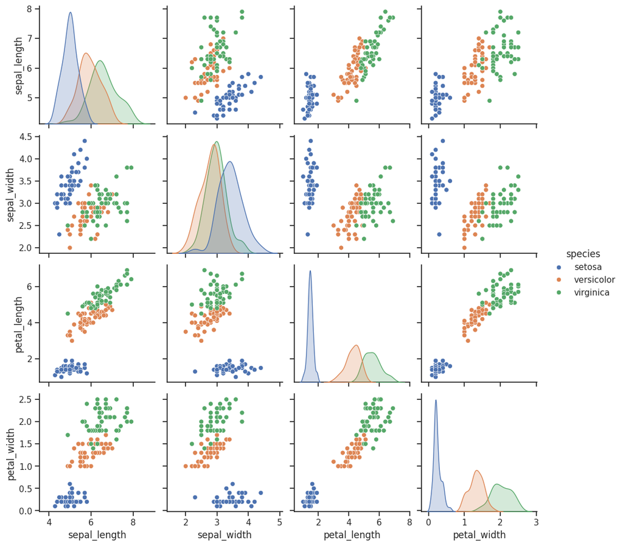

```python
import seaborn as sns
sns.set(style="ticks", color_codes=True)
iris = sns.load_dataset("iris")
g = sns.pairplot(iris, hue="species")
g.savefig("iris.png")
```

```python
#Import libraries
import numpy as np
import pandas as pd
%matplotlib inline
import matplotlib.pyplot as plt
import seaborn as sns
from pandas.plotting import scatter_matrix
```

```python
url = "https://archive.ics.uci.edu/ml/machine-learning-databases/iris/iris.data"
names = ['sepal-length', 'sepal-width', 'petal-length', 'petal-width', 'class']
df = pd.read_csv(url, names=names)
print(df.head(10))
```

```
   sepal-length  sepal-width  petal-length  petal-width        class
0           5.1          3.5           1.4          0.2  Iris-setosa
1           4.9          3.0           1.4          0.2  Iris-setosa
2           4.7          3.2           1.3          0.2  Iris-setosa
3           4.6          3.1           1.5          0.2  Iris-setosa
4           5.0          3.6           1.4          0.2  Iris-setosa
5           5.4          3.9           1.7          0.4  Iris-setosa
6           4.6          3.4           1.4          0.3  Iris-setosa
7           5.0          3.4           1.5          0.2  Iris-setosa
8           4.4          2.9           1.4          0.2  Iris-setosa
9           4.9          3.1           1.5          0.1  Iris-setosa
```

```python
df.tail(10)
```

|  | sepal-length | sepal-width | petal-length | petal-width | class |
| --- | --- | --- | --- | --- | --- |
| 140 | 6.7 | 3.1 | 5.6 | 2.4 | Iris-virginica |
| 141 | 6.9 | 3.1 | 5.1 | 2.3 | Iris-virginica |
| 142 | 5.8 | 2.7 | 5.1 | 1.9 | Iris-virginica |
| 143 | 6.8 | 3.2 | 5.9 | 2.3 | Iris-virginica |
| 144 | 6.7 | 3.3 | 5.7 | 2.5 | Iris-virginica |
| 145 | 6.7 | 3.0 | 5.2 | 2.3 | Iris-virginica |
| 146 | 6.3 | 2.5 | 5.0 | 1.9 | Iris-virginica |
| 147 | 6.5 | 3.0 | 5.2 | 2.0 | Iris-virginica |
| 148 | 6.2 | 3.4 | 5.4 | 2.3 | Iris-virginica |
| 149 | 5.9 | 3.0 | 5.1 | 1.8 | Iris-virginica |

```python
df.describe()
```

|  | sepal-length | sepal-width | petal-length | petal-width |
| --- | --- | --- | --- | --- |
| count | 150.000000 | 150.000000 | 150.000000 | 150.000000 |
| mean | 5.843333 | 3.054000 | 3.758667 | 1.198667 |
| std | 0.828066 | 0.433594 | 1.764420 | 0.763161 |
| min | 4.300000 | 2.000000 | 1.000000 | 0.100000 |
| 25% | 5.100000 | 2.800000 | 1.600000 | 0.300000 |
| 50% | 5.800000 | 3.000000 | 4.350000 | 1.300000 |
| 75% | 6.400000 | 3.300000 | 5.100000 | 1.800000 |
| max | 7.900000 | 4.400000 | 6.900000 | 2.500000 |

```python
print(df.info())
print(df.shape)
```

```
<class 'pandas.core.frame.DataFrame'>
RangeIndex: 150 entries, 0 to 149
Data columns (total 5 columns):
 #   Column        Non-Null Count  Dtype
---  ------        --------------  -----
 0   sepal-length  150 non-null    float64
 1   sepal-width   150 non-null    float64
 2   petal-length  150 non-null    float64
 3   petal-width   150 non-null    float64
 4   class         150 non-null    object
dtypes: float64(4), object(1)
memory usage: 6.0+ KB
None
(150, 5)
```

```python
df.groupby('class').size()
```

| class | 0 |
| --- | --- |
| Iris-setosa | 50 |
| Iris-versicolor | 50 |
| Iris-virginica | 50 |

**dtype:** int64

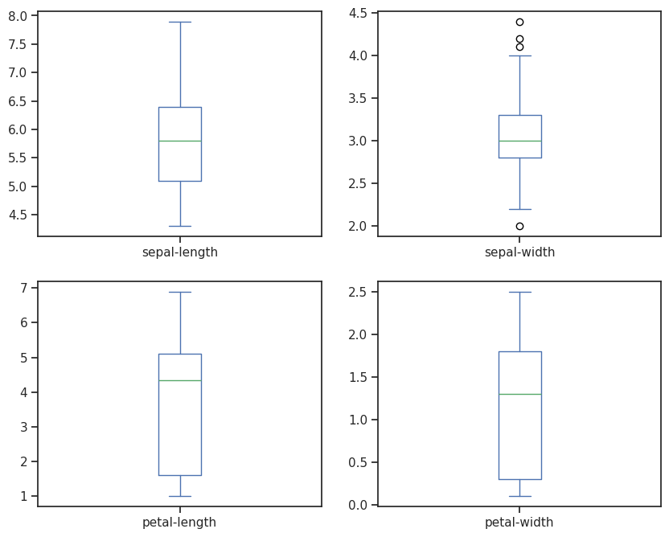

```python
plt.rcParams["figure.figsize"] = (10,8)
df.plot(kind='box', subplots=True, layout=(2,2), sharex=False, sharey=False)
plt.show()
```

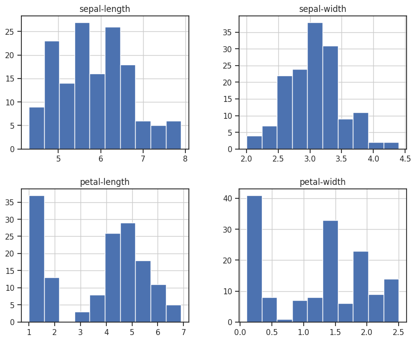

```python
df.hist()
plt.show()
```

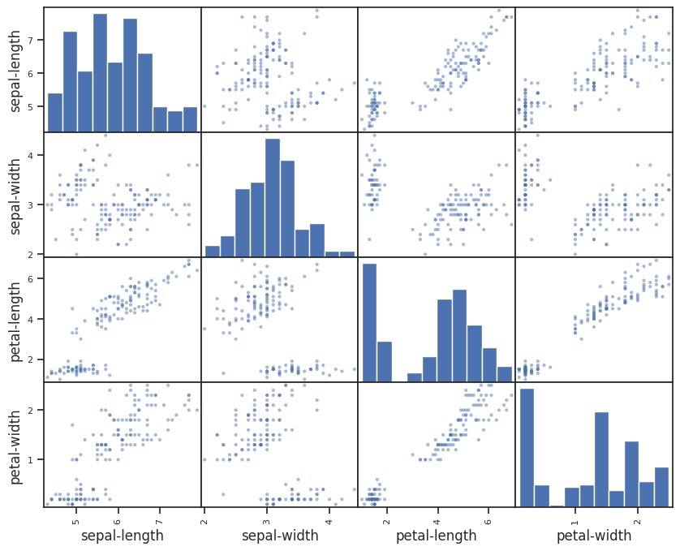

```python
scatter_matrix(df)
plt.show()
```

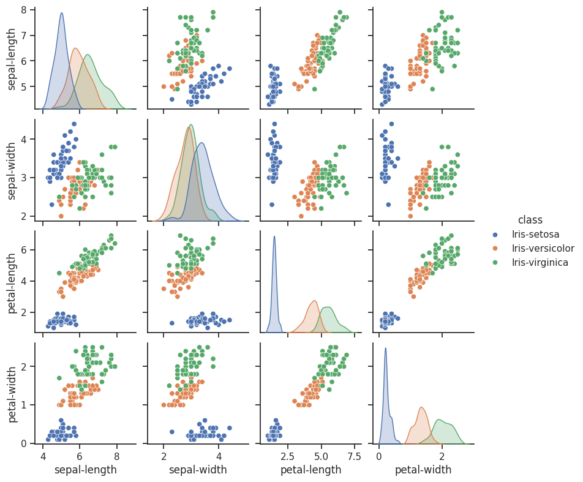

```python
sns.pairplot(df, hue="class", size=2)
```

# ÔN TẬP

## Biến, Kiểu dữ liệu và Khối lệnh

```python
n = 12 # biến n là kiểu nguyên
print(type(n))
n = n + 0.1 # biến n chuyển sang kiểu thực
print(n)
print(type(n))
```

```
<class 'int'>
12.1
<class 'float'>
```

```python
name = 'matt'
# chuỗi trong nó có chứa dấu nháy đơn
with_quote = "I ain't gonna"
# chuỗi có nôi dung nằm trên 2 dòng
longer = """This string has multiple lines in it"""
```

## Nhập và Xuất dữ liệu

```python
#xuất dữ liệu
a = 5
b = 10
print(42)
print("a = ", a)
print("a = \n", a)
print("a","b")
print("a","b",sep="")
print(192,168,178,42,sep=".")
print("a","b",sep=":-)")
```

```
42
a =  5
a =
 5
a b
ab
192.168.178.42
a:-)b
```

```python
name = input("What's your name? ")
print("Nice to meet you " + name + "!")
age = input("Your age? ")
print("You are already " + age + " years old, " + name + "!")
```

```
What's your name? tri
Nice to meet you tri!
Your age? 18
You are already 18 years old, tri!
```

```python
age = int(input("Your age? "))
print("You are already %d years old!", age)
```

```
Your age? 18
You are already %d years old! 18
```

Cho phương trình sau: $$ ax^2 + bx + c = 0, \quad (a \neq 0) $$

được gọi là phương trình bậc 2 với ẩn là (x).

**Công thức nghiệm:** Ta gọi (\Delta = b^2 - 4ac). Khi đó:

- Nếu (\Delta > 0): phương trình tồn tại 2 nghiệm:

  $$ x_1 = \frac{-b + \sqrt{\Delta}}{2a}, \quad x_2 = \frac{-b - \sqrt{\Delta}}{2a} $$
- Nếu (\Delta = 0): phương trình có nghiệm kép:

  $$ x = \frac{-b}{2a} $$
- Nếu (\Delta < 0): phương trình vô nghiệm.

Trong trường hợp (b = 2b'), để đơn giản ta có thể tính:

$$ \Delta' = b'^2 - ac $$

Khi đó:

- Nếu (\Delta' > 0): phương trình có 2 nghiệm phân biệt:

  $$ x_1 = \frac{-b' + \sqrt{\Delta'}}{a}, \quad x_2 = \frac{-b' - \sqrt{\Delta'}}{a} $$
- Nếu (\Delta' = 0): phương trình có nghiệm kép:

  $$ x = \frac{-b'}{a} $$
- Nếu (\Delta' < 0): phương trình vô nghiệm.

```python
a = float(input("A = "))
b = float(input("B = "))
c = float(input("C = "))
delta = b*b-4*a*c
if delta==0:
  print("Nghiem kep: x = ", str(-b/2/a))

if delta<0:
  print("Phuong trinh vo nghiem")

if delta>0:
  print("X1 = " + str((-b+delta**0.5)/2/a))
  print("X2 = " + str((-b-delta**0.5)/2/a))
```

```
A = 5
B = 6
C = 7
Phuong trinh vo nghiem
```

## Kiểu dữ liệu & phép toán

```python
A = 1234 # hệ cơ số 10
B = 0xAF1 # hệ cơ số 16
C = 0o772 # hệ cơ số 8
D = 0b1001 # hệ cơ số 2
print(A,B,C,D)
K = str(1234) # chuyển thành str ở hệ cơ số 10
L = hex(1234) # chuyển thành str ở hệ cơ số 16
M = oct(1234) # chuyển thành str ở hệ cơ số 8
N = bin(1234) # chuyển thành str ở hệ cơ số 2
print(K,L,M,N)
```

```
1234 2801 506 9
1234 0x4d2 0o2322 0b10011010010
```

```python
X = 12.34
Y = 314.15279e-2 # dạng số nguyên và phần mũ 10
A = 3+4j
B = 2-2j
print(A+B) # sẽ in ra (5+2j)
print(X, Y)
print(type(X), type(Y))
```

```
(5+2j)
12.34 3.1415279
<class 'float'> <class 'float'>
```

## Cấu trúc rẽ nhánh

```python
name = input("What's your name? ")
print("Nice to meet you " + name + "!")
age = int(input("Your age? "))
print("You are already", age, "years old,",
name, "!")
if age>=18:
  print("Đủ tuổi đi bầu cử")
if age>100:
  print("Có vẻ sai sai!")
else:
  print("Nhỏ quá")
```

```
What's your name? tri
Nice to meet you tri!
Your age? 18
You are already 18 years old, tri !
Đủ tuổi đi bầu cử
Nhỏ quá
```

```python
A = 5
B = 6
X = A if A > B else B # X là max của A và B
print(X)
```

```
6
```

## VÒNG LẶP

```python
for e in range(10,20): # in các số từ 10 đến 19
  print(e)
print("-"*50)
for d in range(20,10,-1): # in các số từ 20 đến 11
  print(d)
```

```
10
11
12
13
14
15
16
17
18
19
--------------------------------------------------
20
19
18
17
16
15
14
13
12
11
```

## HÀM

```python
def tich(a, b = 1):
  return a*b
```

```python
print(tich(10, 20)) # 200
print(tich(10)) # 10
print(tich(a=5)) # 5
print(tich(b=6, a=5)) # 30
```

```
200
10
5
30
```

## Chuỗi và danh sách

```python
#Chuỗi
#- Phép nối chuỗi (+):
s = "Good" + " " + "Morning!"
print(s)
#- Phép nhân bản (*):
s = "AB" * 3 # số nguyên
print(s)
#- Kiểm tra nội dung:
s in '1ABABABCD' # True
```

```
Good Morning!
ABABAB
```

```
True
```

```python
s = '0123456789'
print(s[3:6]) # 345
print(s[3:]) # 3456789
print(s[:6]) # 012345
print(s[-7:-4]) # 345
print(s[-4:-7]) #
print(s[-4:-7:-1]) # 654
print(s[:len(s)]) # 0123456789
print(s[:len(s) -1]) # 012345678
print(s[:]) # 0123456789
print(s[len(s)::-1]) # 9876543210
print(s[len(s)-1::-1]) # 9876543210
print(s[len(s)-2::-1]) # 876543210
```

```
345
3456789
012345
345

654
0123456789
012345678
0123456789
9876543210
9876543210
876543210
```

```python
myname = 'DHNTT'
s = f'This is {myname}.' # 'This is DHNTT.'
print(s)
w = f'{s} {myname}' # 'This is DHNTT. DHNTT '
print(w)
z = f'{{s}} {s}' # '{s} This is DHNTT.‘
print(z)
```

```
This is DHNTT.
This is DHNTT. DHNTT
{s} This is DHNTT.
```

```python
# điền lần lượt từng giá trị vào giữa cặp ngoặc nhọn
'a: {}, b: {}, c: {}'.format(1, 2, 3)
```

```
'a: 1, b: 2, c: 3'
```

```python
# điền nhưng không lần lượt
'a: {1}, b: {2}, c: {0}'.format('one', 'two', 'three')
```

```
'a: two, b: three, c: one'
```

```python
'two same values: {0}, {0}'.format(1, 2)
```

```
'two same values: 1, 1'
```

```python
# điền và chỉ định từng giá trị
'1: {one}, 2: {two}'.format(one=111, two=222)
```

```
'1: 111, 2: 222'
```

```python
# căn giữa: ' aaaa '
'{:^10}'.format('aaaa')
```

```
'   aaaa   '
```

```python
# căn lề trái: 'aaaa '
'{:<10}'.format('aaaa')
```

```
'aaaa      '
```

```python
# căn lề phải ' aaaa'
'{:>10}'.format('aaaa')
```

```
'      aaaa'
```

```python
# căn lề phải, thay khoảng trắng bằng -: '------aaaa'
'{:->10}'.format('aaaa')
```

```
'------aaaa'
```

```python
# căn lề trái, thay khoảng trắng *: 'aaa******'
'{:*<10}'.format('aaaa')
```

```
'aaaa******'
```

```python
# căn giữa, thay khoảng trắng bằng +: '+++aaaa+++'
'{:+^10}'.format('aaaa')
```

```
'+++aaaa+++'
```

## LIST

```python
a=[1, 2, 3, 4, 5] # list 5 số nguyên
b=['a', 'b', 'c', 'd'] # list 4 chuỗi
c=[[1, 2], [3, 4]] # list 2 list con
d=[1, 'one', [2, 'two']] # list hỗ hợp
e=[] # list rỗng
print(a,"\n",b,"\n",c,"\n",d,"\n",e)
```

```
[1, 2, 3, 4, 5]
 ['a', 'b', 'c', 'd']
 [[1, 2], [3, 4]]
 [1, 'one', [2, 'two']]
 []
```

```python
#Tạo list bằng constructor
l1 = list([1, 2, 3, 4]) # list 4 số nguyên
l2 = list('abc') # list 3 chuỗi con
l3 = list() # list rỗng
print(l1,"\n",l2,"\n",l3)
```

```
[1, 2, 3, 4]
 ['a', 'b', 'c']
 []
```

```python
# Tạo list bằng list comprehension
# list 1000 số nguyên từ 0 đến 999
x = [n for n in range(1000)]
# list gồm 10 list con là các cặp [x, x2]
# với x chạy từ 0 đến 9
y = [[x, x*x] for x in range(10)]
print(x,'\n',y)
```

```
[0, 1, 2, 3, 4, 5, 6, 7, 8, 9, 10, 11, 12, 13, 14, 15, 16, 17, 18, 19, 20, 21, 22, 23, 24, 25, 26, 27, 28, 29, 30, 31, 32, 33, 34, 35, 36, 37, 38, 39, 40, 41, 42, 43, 44, 45, 46, 47, 48, 49, 50, 51, 52, 53, 54, 55, 56, 57, 58, 59, 60, 61, 62, 63, 64, 65, 66, 67, 68, 69, 70, 71, 72, 73, 74, 75, 76, 7…
 [[0, 0], [1, 1], [2, 4], [3, 9], [4, 16], [5, 25], [6, 36], [7, 49], [8, 64], [9, 81]]
```

```python
#Điểm khác biệt là nội dung của list có thể thay đổi
l1 = list([1, 2, 3, 4])
l1[-1] = list('abc')
print(l1)
# [1, 2, 3, ['a', 'b', 'c']]
```

```
[1, 2, 3, ['a', 'b', 'c']]
```

## Tuple (hàng)

```python
a=(1, 2, 3, 4, 5) # tuple 5 số nguyên
b=('a', 'b', 'c', 'd') # tuple 4 chuỗi
c=(1, 'one', [2, 'two']) # tuple hỗ hợp
d=(1,) # tuple 1 phần tử
e=() # tuple rỗng
print(a,"\n",b,"\n",c,"\n",d,"\n",e)
```

```
(1, 2, 3, 4, 5)
 ('a', 'b', 'c', 'd')
 (1, 'one', [2, 'two'])
 (1,)
 ()
```

## Set (tập hợp) và Frozenset (tập hợp tĩnh)

```python
basket = {'apple','orange','apple','pear'}
print(basket)
#{'orange','pear','apple'} : xóa trùng nhau
a = {5,2,3,1,4}
print("a=", a) #a = {1, 2, 3, 4, 5}
```

```
{'pear', 'apple', 'orange'}
a= {1, 2, 3, 4, 5}
```

```python
# Tạo set bằng constructor
s1 = set([1, 2, 3, 4]) # {1, 2, 3, 4}
s2 = set((1, 1, 1)) # {1}
s3 = s1 - s2 # {2, 3, 4}
s4 = set(range(1,100)) # {1, 2, 3,..., 98, 99}
print(s1,"\n",s2,"\n",s3,"\n",s4)
```

```
{1, 2, 3, 4}
 {1}
 {2, 3, 4}
 {1, 2, 3, 4, 5, 6, 7, 8, 9, 10, 11, 12, 13, 14, 15, 16, 17, 18, 19, 20, 21, 22, 23, 24, 25, 26, 27, 28, 29, 30, 31, 32, 33, 34, 35, 36, 37, 38, 39, 40, 41, 42, 43, 44, 45, 46, 47, 48, 49, 50, 51, 52, 53, 54, 55, 56, 57, 58, 59, 60, 61, 62, 63, 64, 65, 66, 67, 68, 69, 70, 71, 72, 73, 74, 75, 76, 77,…
```

```python
#Tạo set bằng set comprehension
# a = {'r', 'd'}
a = {x for x in 'abracadabra' if x not in 'abc'}
print(a)
```

```
{'d', 'r'}
```

```python
#Set không thể chứa những đối tượng mutable (có thể bị thay đổi), mặc dù chính set lại có thể thay đổi
#a = set(([1,2],[2,3])) # lỗi list

a = set(((1,2),(2,3))) # {(1, 2), (2, 3)}
a.add("abc") # {(1, 2), "abc", (2, 3)}
print(a)
```

```
{(2, 3), 'abc', (1, 2)}
```

```python
# Frozenset giống set, nhưng không thể bị thay đổi
b = frozenset(((1,2),(2,3))) # {(1,2), (2,3)}
#b.add("abc") # lỗi
print(b)
```

```
frozenset({(2, 3), (1, 2)})
```

```python
my_set = {8.0, 'Sinh viên', (1, 2, 3)}
print('ketqua_Set=',my_set)
#Output: ketqua_Set= {'Sinh viên', 8.0, (1, 2, 3)}
```

```
ketqua_Set= {8.0, 'Sinh viên', (1, 2, 3)}
```

```python
# Khởi tạo my_set
my_set = {1,3}
my_set.add(2) #thêm
my_set.update([2,3,4]) # Cập nhật
my_set.update([4,5], {1,6,8}) # Cập nhật set
print(my_set)
```

```
{1, 2, 3, 4, 5, 6, 8}
```

```python
a = set('abracadabra') # {'d', 'r', 'c', 'b', 'a'}
b = set('alacazam') # {'z', 'c', 'm', 'l', 'a'}
# Phép Hiệu: thuộc a nhưng không thuộc b

print(a - b) # {'r', 'd', 'b'}

# Phép Hợp: thuộc a hoặc b
# {'a', 'c', 'r', 'd', 'b', 'm', 'z', 'l'}

print(a | b)

# Phép Giao: thuộc cả a và b

print(a & b) # {'a', 'c'}

# Phép Xor: thuộc hoặc a, hoặc b nhưng không phải cả 2
# {'r', 'd', 'b', 'm', 'z', 'l'}
print(a ^ b)
```

```
{'b', 'd', 'r'}
{'r', 'z', 'l', 'd', 'b', 'a', 'm', 'c'}
{'c', 'a'}
{'d', 'r', 'b', 'm', 'z', 'l'}
```

```python
num = {1,3,5,6,8,20,7,8,29,33}
print("Số lớn nhất là :", max(num))
#Số lớn nhất là : 33
```

```
Số lớn nhất là : 33
```

```python
#Ví dụ:
setFruits = {'lemon','orange','apple','pear'}
for x in setFruits:
  print(x)
print('-'*50)
#Ví dụ:
for letter in set("chivuong"):
  print(letter)
```

```
pear
apple
orange
lemon
--------------------------------------------------
u
g
n
v
i
h
o
c
```

## Dictionary (từ điển)

```python
dict = {1:'one',2:'two',3:'three'}
print(dict[1]) #'one'
dict[4]='four'
print(dict)
{1: 'one',2:'two',3:'three',4:'four'}
```

```
one
{1: 'one', 2: 'two', 3: 'three', 4: 'four'}
```

```
{1: 'one', 2: 'two', 3: 'three', 4: 'four'}
```

```python
l1 = ["a","b","c"]
l2 = [1,2,3]
c = zip(l1, l2)
for i in c:
  print(i)
```

```
('a', 1)
('b', 2)
('c', 3)
```

```python
# Ví dụ: Tạo 1 từ diển
# tạo một dict với key là các số nguyên
Dict = {1: 'Nguyen', 2: 'Van', 3: 'An'}
print(Dict)
# {1: ‘Nguyen’, 2: ‘Van’, 3: ‘an’}
```

```
{1: 'Nguyen', 2: 'Van', 3: 'An'}
```

```python
# tạo một dict với key hỗn hợp
Dict = {'Name': 'dict', 1: [1, 2, 3, 4]}
print(Dict)
# {'Name': 'dict', 1: [1, 2, 3, 4]}
```

```
{'Name': 'dict', 1: [1, 2, 3, 4]}
```

```python
# tạo một từ điển
Dict = {}
# thêm các giá trị
Dict[0] = 'Xin chao'
Dict[1] = 'lop hoc Khoa học du lieu'
print(Dict)
# {0: ' Xin chao ', 1: ' Khoa học du lieu'}
```

```
{0: 'Xin chao', 1: 'lop hoc Khoa học du lieu'}
```

```python
# tạo một dict mới
Dict = {1: 'Lớp', 2: 'Khoa học', 3: 'Dữ liệu'}
# truy cập theo cách thông thường
print(Dict[1])
# Lớp
# truy cập bằng phương thức get()
print(Dict.get(3))
# Dữ liệu
```

```
Lớp
Dữ liệu
```

```python
Dict = {'Ten':'An','Tuoi':20};
print("Chuỗi tương đương là :", str(Dict))
#Chuỗi tương đương là : {'Ten': ‘An', 'Tuoi': 20}
```

```
Chuỗi tương đương là : {'Ten': 'An', 'Tuoi': 20}
```

```python
#Hàm update() sẽ thêm vào một giá trị mới, hoặc sẽ cập nhật một giá trị nếu có các khóa trùng nhau.
Dict = {'Cúc':18, 'Lan':19, 'Hồng':20, 'Mai':27}
Dict.update({'Lan':21}) #cập nhật tuổi cho Lan
Dict.update({'Đào':25}) #thêm một phần tử mới là Đào
print(Dict)
#{'Cúc':18,'Lan':21,'Hồng':20,'Mai':27,'Đào':25}
```

```
{'Cúc': 18, 'Lan': 21, 'Hồng': 20, 'Mai': 27, 'Đào': 25}
```

## Module và Package

```python
import numpy as np
#A = array([1, 2, 3]) # lỗi
A = numpy.array([1, 2, 3]) # ok
print(A)
B = np.array([1, 2, 3]) # ok
print(B)
```

```
[1 2 3]
[1 2 3]
```

```python
from numpy import array
C = array([1, 2, 3]) # ok
```

## NUMPY

```python
import numpy as np

a = np.array([1, 2, 3]) # tạo mảng 1 chiều
print(type(a)) # in "<class 'numpy.ndarray'>"
print(a.shape) # in "(3,)"
print(a[0], a[1], a[2]) # in "1 2 3"
a[0] = 5
print(a) # in "[5, 2, 3]"
b = np.array([[1, 2, 3],[4, 5, 6]]) # tạo mảng 2 chiều
print(b.shape) # in "(2, 3)"
print(b[0, 0], b[0, 1], b[1, 0]) # in "1 2 4"
print(np.diag([1, 3, 4])) # in ra cái gì?
```

```
<class 'numpy.ndarray'>
(3,)
1 2 3
[5 2 3]
(2, 3)
1 2 4
[[1 0 0]
 [0 3 0]
 [0 0 4]]
```

```python
x = np.arange(3.0) # mảng [0. 1. 2.]
a = np.zeros((2, 2)) # mảng 2x2 toàn số 0
b = np.ones((1, 2)) # mảng 1x2 toàn số 1
c = np.full((3, 2, 2), 9) # mảng 3x2x2 toàn số 9
d = np.eye(2) # ma trận đơn vị 2x2
e = np.random.randn(3, 2) # mảng 3x2 ngẫu nhiên [0,1)
# mảng 2x3 điền các số từ 1 đến 6, kiểu số nguyên 32 bit
x = np.array([[1, 2, 3], [4, 5, 6]], np.int32)
print(x.ndim, x.size)
print(x.shape) # in "(2, 3)"
print(x.dtype) # in "dtype('int32')"
```

```
2 6
(2, 3)
int32
```

```python
# mảng 3x4
a = np.array([[1, 2, 3, 4], [5, 6, 7, 8], [9, 10, 11, 12]])
# mảng 2x2 trích xuất từ a, dòng 0+1, cột 1+2
b = a[:2, 1:3]
# chú ý: mảng của numpy tham chiếu chứ không copy dữ liệu
print(a[0, 1]) # in "2"
b[0, 0] = 77 # b[0, 0] cũng là a[0, 1]
print(a[0, 1]) # in "77"
```

```
2
77
```

```python
row_r1 = a[1, :] # mảng 1 chiều độ dài 4
row_r2 = a[1:2, :] # mảng 2 chiều 1x4
print(row_r1, row_r1.shape) # in ra "[5 6 7 8] (4,)"
print(row_r2, row_r2.shape) # in ra "[[5 6 7 8]] (1, 4)"
col_r1 = a[:, 1] # mảng 1 chiều độ dài 3
col_r2 = a[:, 1:2] # mảng 2 chiều 3x1
print(col_r1, col_r1.shape) # in ra "[ 2 6 10] (3,)"
print(col_r2, col_r2.shape) # in ra "[[ 2]
                            # [ 6]
                            # [10]] (3, 1)"
```

```
[5 6 7 8] (4,)
[[5 6 7 8]] (1, 4)
[77  6 10] (3,)
[[77]
 [ 6]
 [10]] (3, 1)
```

Các phép toán trên mảng

```python
#NumPy có nhiều phép toán về mảng
x = np.array([[1, 2], [3, 4]], dtype=np.float64)
y = np.array([[5, 6], [7, 8]], dtype=np.float64)
print("1.",x + y) # print(np.add(x, y)), xử lý khác list
print(x - y) # print(np.subtract(x, y))
print(x * y) # print(np.multiply(x, y))
print(x / y) # print(np.divide(x, y))
print(np.sqrt(x)) # khai căn tất cả các phần tử
print(2**x) # tính 2 mũ các phần tử trong x
# chú ý: phép nhân/chia thực hiện theo cặp phần tử của x và y
```

[output not shown]

```python
#Nhân ma trận (dot) và nghịch đảo
x = np.array([[1, 2],[3, 4]])
y = np.array([[5, 6],[7, 8]])
v = np.array([9, 10])
w = np.array([11, 12])
print(v.dot(w)) # tương tự print(np.dot(v, w))
print(x.dot(v)) # tương tự print(np.dot(x, v))
print(x.dot(y)) # tương tự print(np.dot(x, y))
print(np.linalg.inv(x)) # tính và in nghịch đảo của x
```

[output not shown]

```python
#Ma trận chuyển vị
x = np.array([[1, 2], [3, 4]])
print(x) # in ra "[[1 2]
# [3 4]]"
print(x.T) # in ra "[[1 3]
# [2 4]]"
# chú ý: mảng 1 chiều không có chuyển vị
y = np.array([1, 2, 3])
print(y) # in ra "[1 2 3]"
print(y.T) # in ra "[1 2 3]"
z = np.array([[1, 2, 3]])
print(z.T) # đoán xem in ra cái gì?
```

```
[[1 2]
 [3 4]]
[[1 3]
 [2 4]]
[1 2 3]
[1 2 3]
[[1]
 [2]
 [3]]
```

```python
#Đọc dữ liệu từ file
from io import StringIO
import numpy as np
c = StringIO("0 1\n2 3")
x = np.loadtxt(c) # array([[ 0., 1.],
# [ 2., 3.]])
d = StringIO("M 21 72\nF 35 58")
y = np.loadtxt(d, dtype={'names': ('gender','age','weight'),'formats': ('S1', 'i4', 'f4')})
print(y) # [('M', 21, 72.0), ('F', 35, 58.0)]
```

```
[(b'M', 21, 72.) (b'F', 35, 58.)]
```

```python
#Cơ chế broadcasting
x = np.array([[1, 2, 3], [4, 5, 6], [7, 8, 9], [10, 11,12]])
v = np.array([1, 0, 1])
y = x + v
print(y)  # in ra "[[ 2 2 4]
          # [ 5 5 7]
          # [ 8 8 10]
          # [11 11 13]]"
```

```
[[ 2  2  4]
 [ 5  5  7]
 [ 8  8 10]
 [11 11 13]]
```

```python
#Tính tổng theo các trục
x = np.array([[1, 2], [3, 4]])

print(np.sum(x)) # tính tổng toàn bộ x, in "10“
print(np.sum(x, axis=0)) # tính tổng mỗi cột, in "[4 6]“
print(np.sum(x, axis=1)) # tính tổng mỗi hàng, in "[3 7]"
```

```
10
[4 6]
[3 7]
```

```python
#Trích xuất dữ liệu theo dãy
a = np.array([[1,2], [3, 4], [5, 6]])
# Prints "[1 4 5]"
print(a[[0, 1, 2], [0, 1, 0]])
# Prints "[1 4 5]"
print(np.array([a[0, 0], a[1, 1], a[2, 0]]))
# Prints "[2 2]"
print(a[[0, 0], [1, 1]])
# Prints "[2 2]"
print(np.array([a[0, 1], a[0, 1]]))
```

```
[1 4 5]
[1 4 5]
[2 2]
[2 2]
```

```python
#Lọc phần tử theo chỉ số
a = np.array([[1, 2, 3], [4, 5, 6], [7, 8, 9], [10, 11, 12]])
b = np.array([0, 2, 0, 1]) # b là mảng các chỉ số
print(a[np.arange(4), b]) # in ra "[1 6 7 11]"
# cộng tất cả các phần tử được lọc thêm 10
a[np.arange(4), b] += 10
print(a) # in ra "array([[11, 2, 3],
        # [ 4, 5, 16],
        # [17, 8, 9],
        # [10, 21, 12]])
```

[output not shown]

```python
#Lọc dữ liệu theo điều kiện
a = np.array([[1, 2], [3, 4], [5, 6]])
bool_idx = (a > 2)
print(bool_idx) # in ra "[[False False]
# [ True True]
# [ True True]]"
# lọc dữ liệu trong a, trả về một dãy
print(a[bool_idx]) # Prints "[3 4 5 6]"
# có thể viết trực tiếp điều kiện (ngắn gọn hơn)
print(a[a > 2]) # Prints "[3 4 5 6]"
```

```
[[False False]
 [ True  True]
 [ True  True]]
[3 4 5 6]
[3 4 5 6]
```

```python
#Điều chỉnh cỡ ma trận
x = np.array([[1, 3], [4, 4], [4, 2]])
x.shape

x = np.array([[1, 3], [4, 4], [4, 2]])

x = x.reshape(2, 3) #// chỉnh thành 2x3
print(x)
x = np.array([[1, 3], [4, 4], [4, 2]])
x = x.reshape(2, -1) #// tự tính chiều còn lại
print(x)
```

```
[[1 3 4]
 [4 4 2]]
[[1 3 4]
 [4 4 2]]
```

```python
#Elementwise operation
x = np.array([1, 2, 3])
np.log(x) # lấy log cơ số e từng phần tử
print(x)
np.abs(x) # lấy trị tuyệt đối từng phần tử
print(x)
np.maximum(x,2) #lấy max
print(X)
np.minimum(x,2) #lấy min
print(x)
print(x**2) #// lũy thừa
```

[output not shown]

norm cấp 2 của vector là chiều dài của vector đó

$$ \|x\|_2 = |x| = \sqrt{x_1^2 + x_2^2 + \cdots + x_n^2} $$

```python
x = np.array([[0, 3], [4, 3], [6, 8]])
print(x)

# tính norm mỗi dòng, kết quả: array([[3], [5], [10]])
np.linalg.norm(x, axis = 1, keepdims = True)
x = np.array([[0, 6], [4, 0], [3, 8]])
print(x)

# tính norm mỗi cột, kết quả: array([[5, 10]])
np.linalg.norm(x, axis = 0, keepdims = True)
```

```
[[0 3]
 [4 3]
 [6 8]]
[[0 6]
 [4 0]
 [3 8]]
```

```
array([[ 5., 10.]])
```

```python
#Sinh mảng ngẫu nhiên
a = np.random.randn(3, 2) # mảng 3x2 ngẫu nhiên trong [0,1)
b = np.random.randn() # một số sinh theo phân phối chuẩn
c = np.random.randn(3) # mảng 3 số theo phân phối chuẩn
d = np.random.randn(3, 4) # mảng 3x4 theo phân phối chuẩn
# mảng 2x4 gồm các số nguyên trong [3,15)
e = np.random.randint(3, 15, (2, 4))
# sinh một dãy là hoán vị ngẫu nhiên của dãy (0, 1, 2,..., 19)
f = np.random.permutation(20)
print(f'a= {0} \n b= {1} \n c= {3} \n d= {4} \n e={5} \n f= {6}', a, b,c,d,e,f)
```

```
a= 0
 b= 1
 c= 3
 d= 4
 e=5
 f= 6 [[ 0.56119731 -0.26177014]
 [-0.35666068  1.36637362]
 [ 0.98018818 -1.92099504]] 0.34437125295851806 [ 1.99910206 -0.48694488  0.19842317] [[-0.47482633 -1.08978939  1.20100779  0.792303  ]
 [ 0.88862635  1.43583126  0.43460459  1.50260382]
 [-0.68449374  0.16234738 -0.30677516  0.35016597]] [[12  9 14  8]
 [11  8 13 13]] [ 7  0 14  3 11 16 19  1 18  9 10 17 15 13  6  5  8  4  2 12]
```

```python
#Các hàm thống kê
import numpy as np
a = np.random.randn(3, 4)
# tính trung bình của cả ma trận a
print(np.mean(a))
# tính trung vị của cột đầu tiên
print(np.median(a[:,0]))
# tính độ lệch chuẩn của từng dòng
print(a.std(axis=0))
# tính phương sai của từng cột
print(a.var(axis=1))
```

```
0.007460074937519545
0.7630897467830703
[1.09187361 1.49467666 0.70148933 0.49691189]
[1.90395704 0.43104596 0.70523679]
```

## MATPLOTLIB

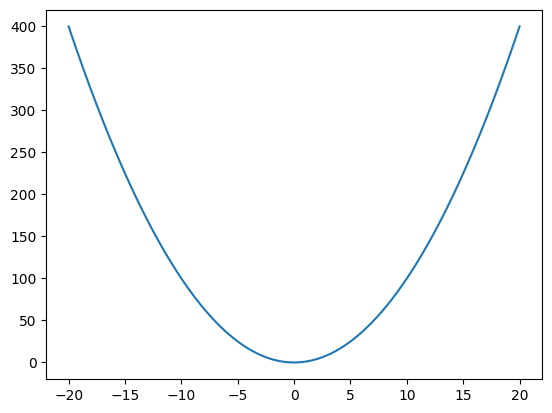

```python
#Ví dụ: vẽ biểu đồ y = x2
import numpy as np # thư viện numpy
import matplotlib.pyplot as plt # thư viện pyplot

# chia đoạn từ -20 đến 20 thành 1000 đoạn
x = np.linspace(-20, 20, 1000)
# tính y
y = x * x
# vẽ biểu đồ tương quan giữa x và y
plt.plot(x, y)
# hiển thị biểu đồ
plt.show()
```

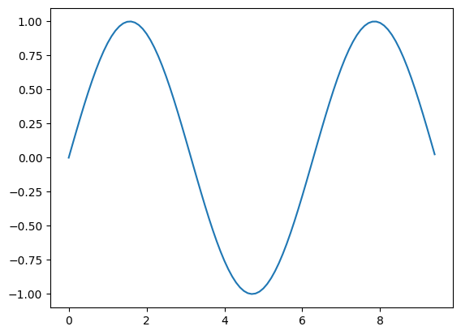

```python
#Ví dụ: Vẽ biểu đồ hình sin
import numpy as np # thư viện numpy
import matplotlib.pyplot as plt # thư viện pyplot

# chia đoạn từ 0 đến 3π thành các đoạn con 0.1
x = np.arange(0, 3 * np.pi, 0.1)
# tính sin tương ứng với từng phần tử của x
y = np.sin(x)
# vẽ biểu đồ tương quan giữa x và y
plt.plot(x, y)
# hiển thị biểu đồ
plt.show()
```

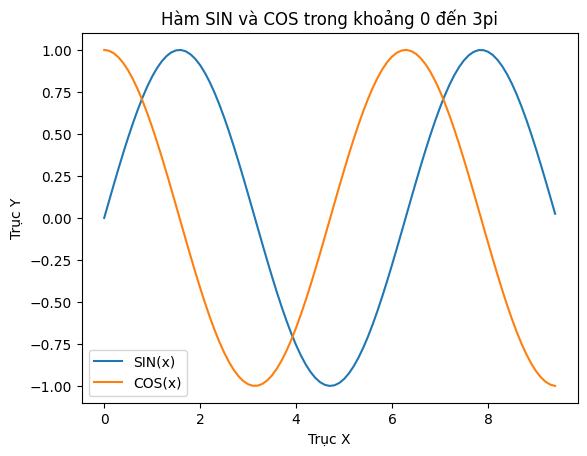

```python
#Ví dụ: Biểu đồ cả SIN và COS
x = np.arange(0, 3 * np.pi, 0.1)
y_sin = np.sin(x)
y_cos = np.cos(x)
plt.plot(x, y_sin)
plt.plot(x, y_cos)
plt.xlabel('Trục X')
plt.ylabel('Trục Y')
plt.title('Hàm SIN và COS trong khoảng 0 đến 3pi')
plt.legend(['SIN(x)', 'COS(x)'])
plt.show()
```

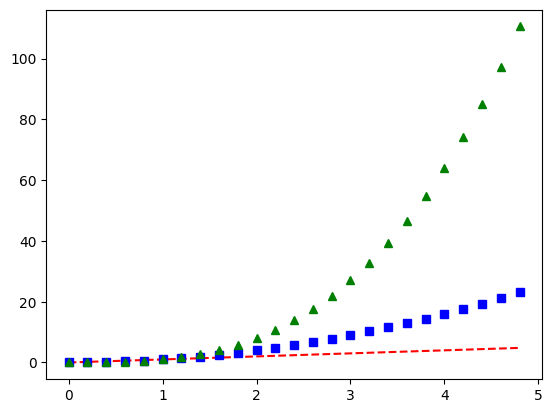

```python
#LINE PLOT
# chia đoạn 0-5 thành các bước 0.2
t = np.arange(0., 5., 0.2)
# Vẽ 3 đường: #- màu đỏ nét đứt: y = x
#- màu xanh dương, đánh dấu ô vuông:
y = pow(x,2)
#- màu xanh lá, đánh dấu tam giác:
y = pow(x,3)
plt.plot(t, t, 'r--', t, t**2, 'bs', t, t**3, 'g^')
plt.show()
```

BAR PLOT

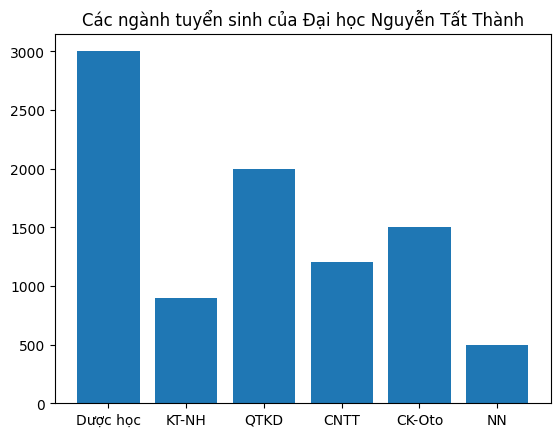

```python
#Biểu đồ dạng cột chiều đứng
import matplotlib.pyplot as plt
D = { 'Dược học': 3000,
      'KT-NH': 900,
      'QTKD': 2000,
      'CNTT': 1200,
      'CK-Oto': 1500,
      'NN': 500 }
plt.bar(range(len(D)), D.values(), align='center')
plt.xticks(range(len(D)), D.keys())
plt.title('Các ngành tuyển sinh của Đại học Nguyễn Tất Thành')
plt.show()
```

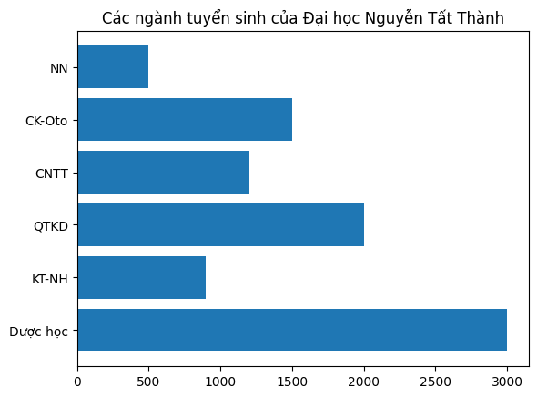

```python
#Biểu đồ dạng cột chiều ngang
import matplotlib.pyplot as plt
D = { 'Dược học': 3000,
      'KT-NH': 900,
      'QTKD': 2000,
      'CNTT': 1200,
      'CK-Oto': 1500,
      'NN': 500 }
plt.barh(range(len(D)), D.values(), align='center')
plt.yticks(range(len(D)), D.keys())
plt.title('Các ngành tuyển sinh của Đại học Nguyễn Tất Thành')
plt.show()
```

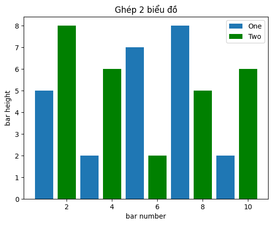

```python
#Có thể ghép 2 biểu đồ
import matplotlib.pyplot as plt

plt.bar([1,3,5,7,9],[5,2,7,8,2], label="One")
plt.bar([2,4,6,8,10],[8,6,2,5,6], label="Two", color='g')
plt.legend()
plt.xlabel('bar number')
plt.ylabel('bar height')
plt.title('Ghép 2 biểu đồ')
plt.show()
```

Biểu đồ bánh (pie chart)

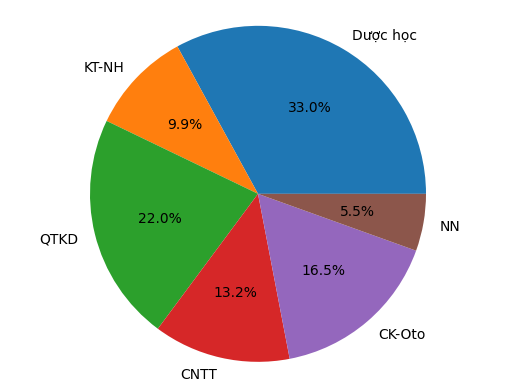

```python
import matplotlib.pyplot as plt
D = { 'Dược học': 3000,
      'KT-NH': 900,
      'QTKD': 2000,
      'CNTT': 1200,
      'CK-Oto': 1500,
      'NN': 500 }
plt.pie(D.values(), labels=D.keys(), autopct='%1.1f%%')
plt.axis('equal') # trục x = trục y
plt.show()
```

Một số chức năng hữu ích

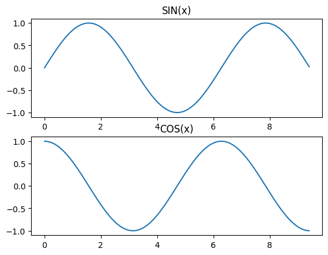

```python
#Chia thành các biểu đồ con
import numpy as np
import matplotlib.pyplot as plt
x = np.arange(0, 3 * np.pi, 0.1)
y_sin = np.sin(x)
y_cos = np.cos(x)
plt.subplot(2, 1, 1) # biểu đồ 1
plt.plot(x, y_sin)
plt.title('SIN(x)')
plt.subplot(2, 1, 2) # biểu đồ 2
plt.plot(x, y_cos)
plt.title('COS(x)')
plt.show()
```

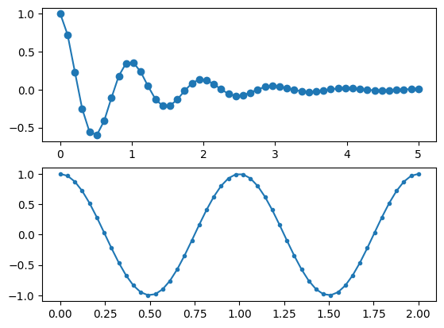

```python
x1 = np.linspace(0.0, 5.0)
x2 = np.linspace(0.0, 2.0)
y1 = np.cos(2 * np.pi * x1) * np.exp(-x1)
y2 = np.cos(2 * np.pi * x2)
plt.subplot(2, 1, 1)
plt.plot(x1, y1, 'o-')
plt.subplot(2, 1, 2)
plt.plot(x2, y2, '.-')
plt.show()
```

[figure not shown]

```python
#Nạp ảnh (png_jpg)
import matplotlib.pyplot as plt
import matplotlib.image as mpimg

image = mpimg.imread("ảnh mèo đen gốc.jpg")
fig, axs = plt.subplots(2, 2, figsize=(5, 5))
axs[0,0].imshow(image)
axs[1,0].imshow(image)
axs[0,1].imshow(image)
axs[1,1].imshow(image)
plt.show()
```

[figure not shown]

```python
import matplotlib.pyplot as plt
import matplotlib.image as mpimg

image = mpimg.imread("ảnh mèo đen gốc.jpg")
fig, axs = plt.subplots(2, 2, figsize=(5, 5))
axs[0, 0].imshow(image)
axs[1, 0].imshow(image)
axs[0, 1].imshow(image)
axs[1, 1].imshow(image)

plt.savefig('1.jpg')
plt.savefig('1.pdf')
```

## PANDAS

Làm việc với series

```python
#Làm việc với series
import pandas as pd
import numpy as np

S = pd.Series(np.random.randint(100, size = 4))
print(S)
print(S.index)
print(S.values)
```

```
0    36
1    42
2    22
3    67
dtype: int64
RangeIndex(start=0, stop=4, step=1)
[36 42 22 67]
```

```python
import pandas as pd
import numpy as np

chi_so = ["Ke toan", "KT", "CNTT", "Co khi"]
gia_tri = [310, 360, 580, 340]
S = pd.Series(gia_tri, index=chi_so)
print(S)
print(S.index)
print(S.values)
```

```
Ke toan    310
KT         360
CNTT       580
Co khi     340
dtype: int64
Index(['Ke toan', 'KT', 'CNTT', 'Co khi'], dtype='object')
[310 360 580 340]
```

```python
import pandas as pd
import numpy as np

chi_so = ["KT", "KT", "CNTT", "Co khi"] # trùng nhau
gia_tri = [310, 360, 580, 340]
S = pd.Series(gia_tri, index=chi_so)
print(S)
print(S.index)
print(S.values)
```

```
KT        310
KT        360
CNTT      580
Co khi    340
dtype: int64
Index(['KT', 'KT', 'CNTT', 'Co khi'], dtype='object')
[310 360 580 340]
```

```python
#Truy vấn dữ liệu thông qua chỉ số
import pandas as pd
import numpy as np

chi_so = ["KT", "KT", "CNTT", "Co khi"] # trùng nhau
gia_tri = [310, 360, 580, 340]
S = pd.Series(gia_tri, index=chi_so)
print(S['Co khi'])
print(S['KT'])
print(S.CNTT)
```

```
340
KT    310
KT    360
dtype: int64
580
```

```python
#Phép toán trên series
import pandas as pd
import numpy as np

chi_so = ["Ke toan", "KT", "CNTT", "Co khi"]
gia_tri = [310, 360, 580, 340]
# chỉ số giống nhau thì tính gộp, nếu không thì NaN
S = pd.Series(gia_tri, index=chi_so)
P = pd.Series([100, 100], ['CNTT','PM'])
Y = S + P
print(Y)
```

```
CNTT       680.0
Co khi       NaN
KT           NaN
Ke toan      NaN
PM           NaN
dtype: float64
```

```python
#apply() một hàm khác trên series
def Tang(x):
  return x if x > 500 else x + 1000

chi_so = ["Ke toan", "KT", "CNTT", "Co khi"]
gia_tri = [310, 360, 580, 340]
S = pd.Series(gia_tri, chi_so)
# áp dụng Tang trên S (không thay đổi S)
print(S.apply(Tang))
```

```
Ke toan    1310
KT         1360
CNTT        580
Co khi     1340
dtype: int64
```

Làm việc với dataframe

```python
#tạo dataframe từ list
crimes_rates = {  "Year":[1960,1961,1962,1963,1964],
                  "Population":[179323175,182992000,185771000,188483000, 191141000],
                  "Total":[3384200,3488000,3752200,4109500,4564600],
                  "Violent":[288460,289390,301510,316970,364220]}
crimes_dataframe = pd.DataFrame(crimes_rates)
print(crimes_dataframe)
```

```
   Year  Population    Total  Violent
0  1960   179323175  3384200   288460
1  1961   182992000  3488000   289390
2  1962   185771000  3752200   301510
3  1963   188483000  4109500   316970
4  1964   191141000  4564600   364220
```

```python
#Tạo dataframe từ list các dictionary
data = [  {'MIT': 5000, 'Stanford': 4500, "DHTL":15000},
          {'MIT': 1, 'Stanford': 2, "DHTL":200}]
df = pd.DataFrame(data, index=['NumOfStudents', "ranking"])
print(df)
print(df.DHTL.dtype)
```

```
                MIT  Stanford   DHTL
NumOfStudents  5000      4500  15000
ranking           1         2    200
int64
```

```python
#Tạo dataframe từ dictionary serias
data = {  "one": pd.Series([1,23,45], index = [1,2,3]),
          "two": pd.Series([1000,2400,1132,3434], index =[1,2,3,4])}
df = pd.DataFrame(data)
print(df)
```

```
    one   two
1   1.0  1000
2  23.0  2400
3  45.0  1132
4   NaN  3434
```

```python
#Đọc dữ liệu từ file .csv
import pandas as pd

d = pd.read_csv("brics.csv")
print(d)
```

```
  Unnamed: 0       country  population      area    capital
0         BR        Brazil         200   8515767   Brasilia
1         RU        Russia         144  17098242     Moscow
2         IN         India        1252   3287590  New Delhi
3         CH         China        1357   9596961    Beijing
4         SA  South Africa          55   1221037   Pretoria
```

```python
# đọc dữ liệu và quy định cột 0 dùng làm chỉ số dòng
d = pd.read_csv("brics.csv", index_col = 0)
print(d)
```

```
         country  population      area    capital
BR        Brazil         200   8515767   Brasilia
RU        Russia         144  17098242     Moscow
IN         India        1252   3287590  New Delhi
CH         China        1357   9596961    Beijing
SA  South Africa          55   1221037   Pretoria
```

```python
print(d.country)
```

```
BR          Brazil
RU          Russia
IN           India
CH           China
SA    South Africa
Name: country, dtype: object
```

```python
print(d['country'])
```

[output not shown]

```python
d["on earth"] = ["true", "true", "true", 'true', "true"]
print(d)
```

[output not shown]

```python
d['destiny'] = d['population'] / d['area'] * 10000
print(d)
```

[output not shown]

```python
print(d.loc['CH', 'capital'])
print(d['capital'].loc['CH'])
print(d.loc['CH']['capital'])
```

```
Beijing
Beijing
Beijing
```

```python
#Xóa dòng hoặc cột bằng drop
# tạo ra dataframe mới bằng cách xóa 2 cột
print(d.drop(["area", "population"], axis=1))
# trường hợp muốn xóa trên d, thêm tham số inplace=True
d.drop(["area", "population"], axis=1, inplace=True)
print(d)
```

[output not shown]

```python
#Tính tổng và tổng tích lũy
# tính tổng của cột population, trả về tổng
print(d.population.sum())
# tính tổng của cột population, trả về các tổng trong quá trình cộng
print(d.population.cumsum())
```

```
3008
0     200
1     344
2    1596
3    2953
4    3008
Name: population, dtype: int64
```

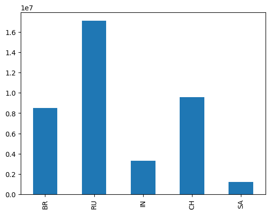

```python
#Kết hợp giữa pandas và matplotlib
import pandas as pd
import matplotlib.pyplot as plt
d = pd.read_csv("brics.csv", index_col = 0)
d.area.plot(kind='bar')
plt.show()
```

```python
#nhóm phân tử
df2 = pd.DataFrame({'X' : ['B', 'B', 'A', 'A'], 'Y' : [1, 2, 3, 4]})
df2.groupby(['X']).sum()
```

| X | Y |
| --- | --- |
| A | 7 |
| B | 3 |

```python
df2.groupby(['X'], sort=False).sum()
```

| X | Y |
| --- | --- |
| B | 3 |
| A | 7 |

```python
df3 = pd.DataFrame({'X' : ['A', 'B', 'A', 'B'], 'Y' :[1, 4, 3, 2]})
df3.groupby(['X']).get_group('A')
```

|  | X | Y |
| --- | --- | --- |
| 0 | A | 1 |
| 2 | A | 3 |

```python
df3.groupby(['X']).get_group('B')
```

|  | X | Y |
| --- | --- | --- |
| 1 | B | 4 |
| 3 | B | 2 |

KẾT THÚC